# Rodzaje reszt w modelu Coxa

Magdalena Mazurek

14 stycznia 2017

# Wstęp

**Cel:**

Zaznajomienie się (bądź przypomnienie) z podstawowymi pojęciami analizy przeżycia oraz z rodzajami reszt w modelu Coxa.

**Motywacje:**

Sprawdzenie czy jest możliwe wykorzystanie reszt w modelach wielostanowych, w szczególności w konkurencyjnych ryzykach.

# Co chcemy modelować?

$T$ - czas do wystąpienia zdarzenia (zgon/nawrót choroby/ progersja choroby), ale …

- pacjenci mogą rezygnować w trakcie leczenia,
- u pacjentów dane zdarzenie może nie wystąpić,
- i wiele innych.

# Co to jest *cenzurowanie*?

Występują zatem sytuacje, dla których nie obserwujemy dokładnego czasu zdarzenia $T$.

Mamy wtedy do czynienia z *cenzurowaniem*.

Możemy obserwować różne typy cenzurowania, takie jak:

- prawostronne,
- lewostronne,
- przedziałowe.

# Zapis formalny

- $\tilde{T} \geq 0$ - zmienna losowa opisująca czas do wystąpienia zdarzenia
- $C \geq 0$ - zmienna losowa opisująca czas cenzurowania

Dla cenzurowania prawostronnego obserwujemy czas do wystąpenia zdarzenia:
$$T = min(\tilde{T}, C)$$

W praktyce obserwujemy pary $(T,\delta)$, gdzie $\delta=\mathbb{I}(\tilde{T}, C)$ jest wskaźnikiem cenzurowania.

| patientID | intens | time | vomit |
| --- | --- | --- | --- |
| 1 | 1 | 30 | 1 |
| 2 | 1 | 50 | 1 |
| 3 | 1 | 50 | 0 |
| 4 | 1 | 51 | 1 |
| 5 | 1 | 66 | 0 |
| 6 | 1 | 82 | 1 |

# Zapis formalny

Funkcja przeżycia: $S(t) = \mathbb{P}(\tilde{T} \geq t)$. *Uwaga!* $S(0)=1$

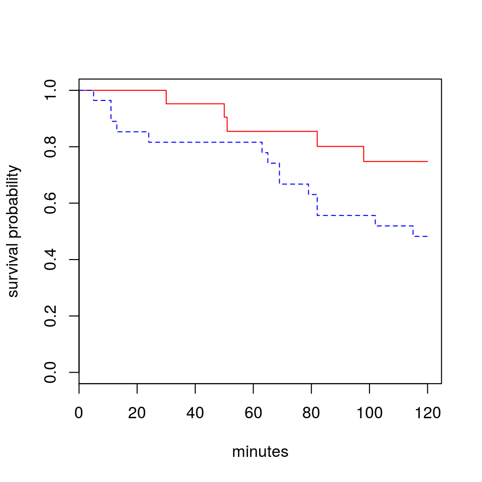

Funkcja hazardu: $\lambda(t) = \lim\limits_{h \rightarrow 0^+} \frac{\mathbb{P}(t \leq \tilde{T} < t+h | \tilde{T} \geq t)}{h}$.

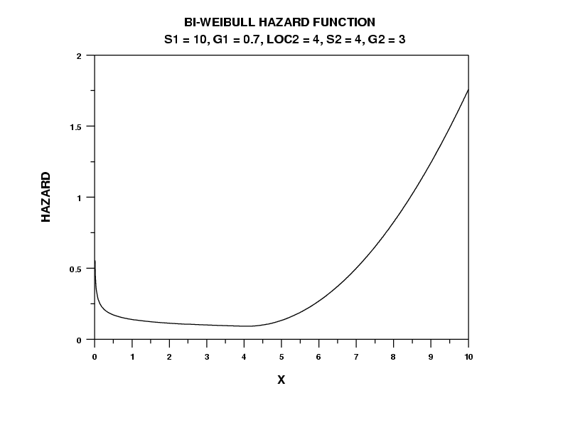

Zależność występująca pomiędzypowyższymi funkcjami:
$$S(t) = e^{-\int\limits_0^t \lambda(u)du}$$

# Model Coxa

Załóżmy, że mamy wektor zmiennych niezależnych:
$$\textbf{Z}(t)'=(Z_1(t),Z_2(t),\ldots,Z_p(t))$$
Model Coxa zakłada następującą postać funkcji hazardu:
$$\lambda(t,\textbf{Z}(t))=\lambda_0(t)\cdot e^{\beta'\textbf{Z}(t)}$$

Dla $\textbf{Z}(t)=\textbf{Z}$ otrzymujemy model **proporcjonalnych hazardów**.

# Model proporcjonalnych hazardów

Interpretacja założenia: Niech $\textbf{Z}$ będzie zmienną opisującą wielkość guza:

- $\textbf{Z} = 0$ ozn. mały guz (I),
- $\textbf{Z} = 1$ ozn. średni guz (II),
- $\textbf{Z} = 2$ ozn. duży guz (III).

Wówczas funkcja hazardu dla poszczególnych rozmiarów guza wynosi:

- mały guz: $\lambda_I(t) = \lambda_0(t) \cdot e^{0 \cdot \beta} = \lambda_0(t)$
- średni guz: $\lambda_{II}(t) = \lambda_0(t) \cdot e^{1 \cdot \beta} = \lambda_0(t) \cdot e^{\beta}$
- duży guz: $\lambda_{III}(t) = \lambda_0(t) \cdot e^{2 \cdot \beta} = \lambda_0(t) \cdot e^{2\beta}$

Model zakłada, że wzrost $\textbf{Z}$ o 1 zwiększa hazard o $e^\beta$ razy.

# Jak sprawdzić założenie modelu?

Wykres skalowanych reszt Schoenfelda dla pewnej funkcji czasu $g(t)$.

Dla czasów zdarzeń $t_{(k)}$:
$$\hat{r}_{Sk} = \sum\limits_{i: t_{(i)}=t_{(k)}} \big\{ Z_{(k)}(t_{(k)}) - \overline{Z}(\hat{\beta},t_{(k)}) \big\}^T$$
$$\hat{r}_{Sk}^* = \hat{r}_{Sk} Var^{-1}(\hat{\beta},t_{(k)})$$

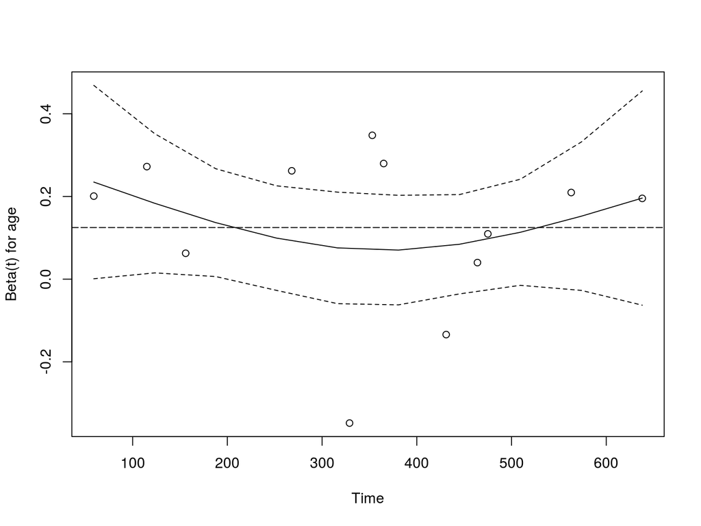

```r
model_PH <- coxph(Surv(futime,fustat)~., data=ovarian)
model_PH_test<-cox.zph(model_PH,transform = "identity")
plot(model_PH_test, df=3, nsmo=10, se=TRUE, var=1)
abline(model_PH$coeff[1], 0, lty=5)
```

# Postać funkcyjna zmiennych niezależnych

Reszty martyngałowe vis ciągła zmienna niezależna.

$$M(t) = N(t) - \int\limits_0^t Y(u) \lambda_0 (u) e^{\beta^t Z(u)} du$$
gdzie $N(t)$ to procez zliczający zdarzenia, $Y(t)$ to proces zbioru ekspozycji na ryzyko zdarzenia.

# Postać funkcyjna zmiennych niezależnych

Jak znaleźć odpowiednie przekształcenie?

- dopasowujemy model “pusty”
- rysujemy wykres reszt martyngałowych dla danej zmiennej
- wygładzamy wykres dla ustalenia funkcji

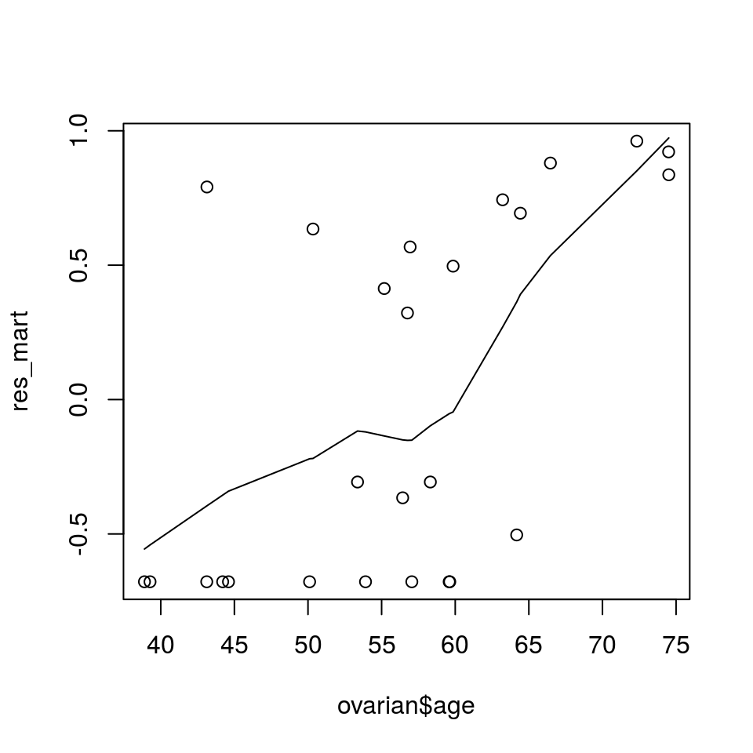

```r
model_PH <- coxph(Surv(futime,fustat)~1, data=ovarian)
res_mart <- resid(model_PH)
plot(ovarian$age, res_mart)
lines(lowess(ovarian$age, res_mart, iter=0, f=0.6))
```

# Dopasowanie modelu

Wykres reszt martyngałowych (lub dewiancji) vis liniowa kombinacja zmiennych.

Reszty oparte na dewiancji dla zmiennych niezależnych stałych w czasie:
$$\hat{r}_{Di} = \text{sign}(\hat{M}_i) \sqrt{-\hat{M}_i - \delta_i \log(\delta_i - \hat{M}_i)}$$

*Uwaga!* Z reguły reszty są symetrczne i mieszczą się w przedziale $(-2,2)$.

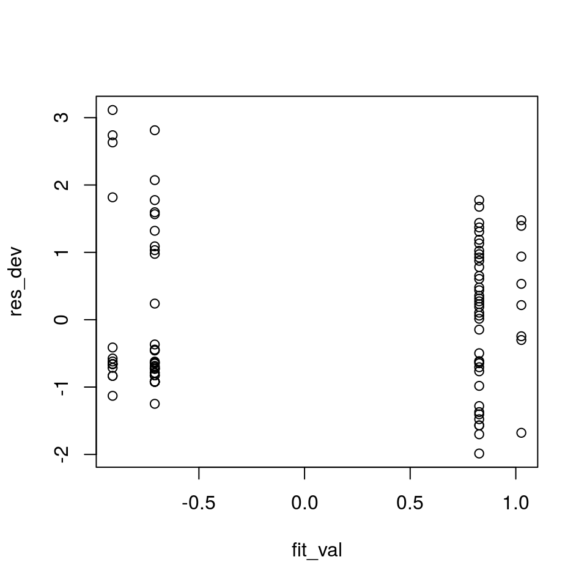

```r
model_PH <- coxph(Surv(survtime, survind) ~ mutation + expression, data=nsclc)
res_dev <- residuals(model_PH,type="deviance")
fit_val <- predict(model_PH,type="lp")
plot(fit_val, res_dev)
```

# Obserwacje wpływowe

Reszty score vis zmienna niezależna.

Reszta “score” dla obserwacji *i* i zmiennej *j*:
$$\hat{r}_{U_{ij}} = U_{ij} (\hat{\beta},\infty), \qquad U_{ijk}(\beta) = \int\limits_{t_{(k-1)}}^{t_k} \big\{ Z_{ij}(u) - \overline{Z}_j(\beta,u) \big\} dM_i(u)$$

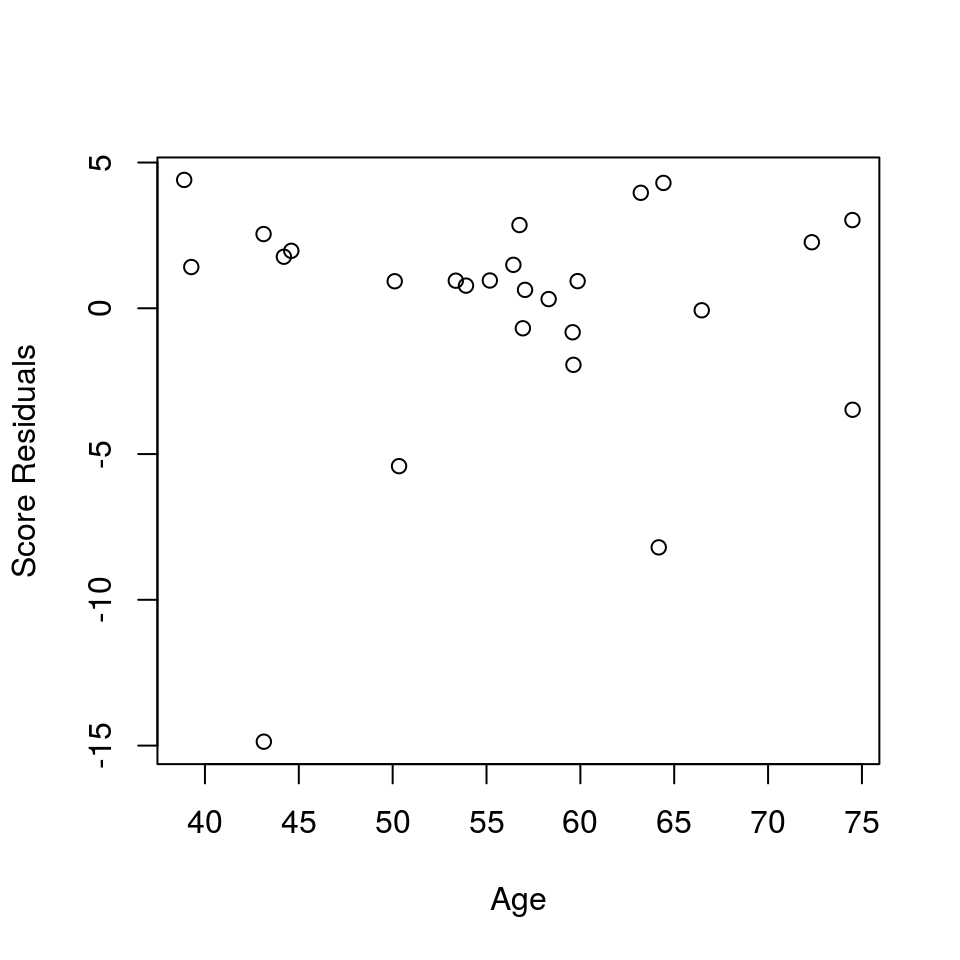

```r
model_PH <- coxph(Surv(futime,fustat)~., data=ovarian)
score <- resid(model_PH, type="score")
plot(ovarian$age, score[,1], ylab="Score Residuals", xlab="Age")
```

# Konkurencyjne ryzyka a reszty - pakiet `survival`

Postać danych

| patnr | time | status | cause | ccr5 |
| --- | --- | --- | --- | --- |
| 1 | 9.106 | 1 | AIDS | WW |
| 2 | 11.039 | 0 | event-free | WM |
| 3 | 2.234 | 1 | AIDS | WW |
| 4 | 9.878 | 2 | SI | WM |
| 5 | 3.819 | 1 | AIDS | WW |

Dane przekształcone

| patnr | time | status | cause | ccr5 | event | si |
| --- | --- | --- | --- | --- | --- | --- |
| 1 | 9.106 | 1 | AIDS | WW | 1 | 2 |
| 2 | 11.039 | 0 | event-free | WM | 0 | 0 |
| 3 | 2.234 | 1 | AIDS | WW | 1 | 2 |
| 4 | 9.878 | 2 | SI | WM | 1 | 1 |
| 5 | 3.819 | 1 | AIDS | WW | 1 | 2 |

Model PH dal funkcji hazardu

```r
coxph_aids <- coxph(Surv(time, status == 1) ~ ccr5, data = aidssi)
coxph_si <- coxph(Surv(time, status == 2) ~ ccr5, data = aidssi)
```

Reszty Schoenfelda

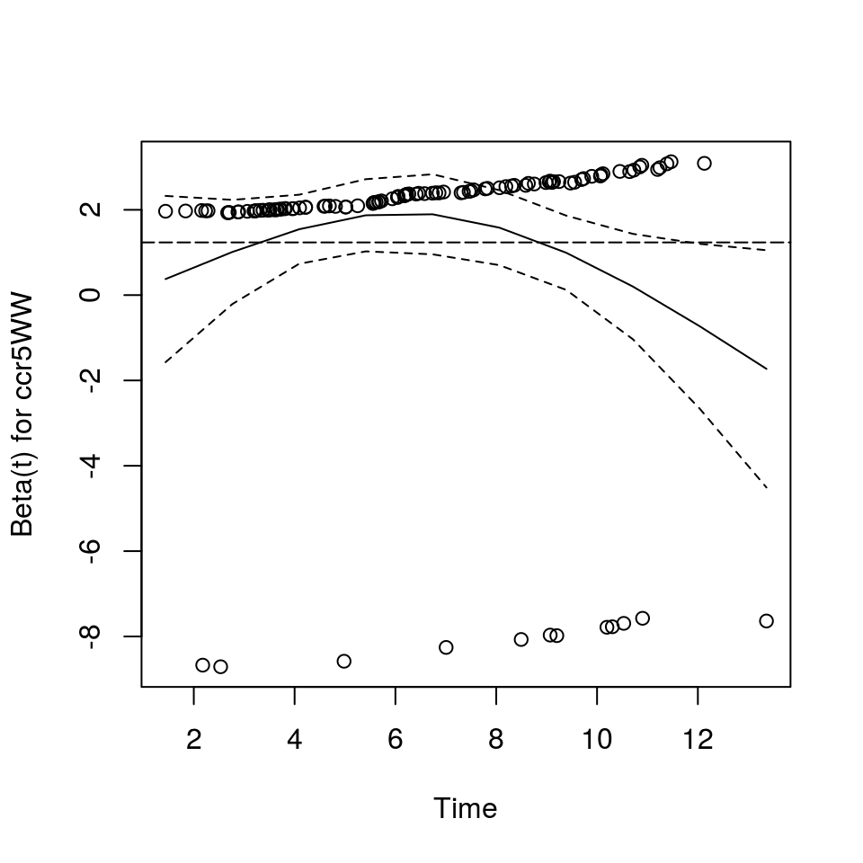

```r
model_PH_test<-cox.zph(coxph_aids,transform = "identity")
plot(model_PH_test, df=3, nsmo=10, se=TRUE, var=1)
abline(coxph_aids$coeff[1], 0, lty=5)
```

Reszty dewiancji

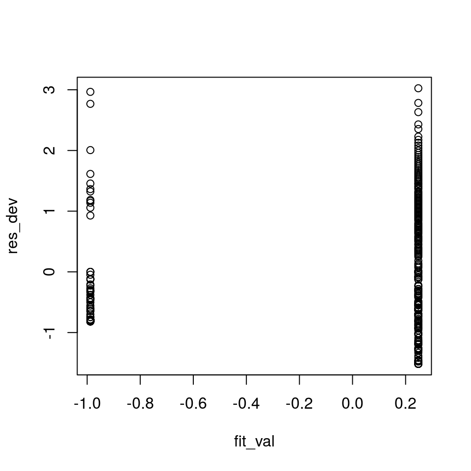

```r
res_dev <- residuals(coxph_aids,type="deviance")
fit_val <- predict(coxph_aids,type="lp")
plot(fit_val, res_dev)
```

# Konkurencyjne ryzyka a reszty - pakiet `mstate`

```r
library(mstate)
tmat <- transMat(list(c(2,3,5,6), c(4,5,6), c(4,5,6), c(5,6), c(), c()),
  names=c("Tx", "Rec", "AE", "Rec+AE", "Rel", "Death"))
msebmt <- msprep(
  data = ebmt4, trans = tmat,
  time = c(NA, "rec", "ae", "recae", "rel", "srv"),
status = c(NA, "rec.s", "ae.s", "recae.s", "rel.s", "srv.s"),
  keep = c("match", "proph", "year", "agecl"))
msebmt2 <- expand.covs(msebmt, longnames = FALSE, c("match", "proph", "year", "agecl"))
msebmt2[, c("Tstart", "Tstop", "time")] <- msebmt2[, c("Tstart", "Tstop", "time")]/365.25
knitr::kable(msebmt2[msebmt2$id == 1, (1:9)])
```

| id | from | to | trans | Tstart | Tstop | time | status | match |
| --- | --- | --- | --- | --- | --- | --- | --- | --- |
| 1 | 1 | 2 | 1 | 0.0000000 | 0.0602327 | 0.0602327 | 1 | no gender mismatch |
| 1 | 1 | 3 | 2 | 0.0000000 | 0.0602327 | 0.0602327 | 0 | no gender mismatch |
| 1 | 1 | 5 | 3 | 0.0000000 | 0.0602327 | 0.0602327 | 0 | no gender mismatch |
| 1 | 1 | 6 | 4 | 0.0000000 | 0.0602327 | 0.0602327 | 0 | no gender mismatch |
| 1 | 2 | 4 | 5 | 0.0602327 | 2.7241615 | 2.6639288 | 0 | no gender mismatch |
| 1 | 2 | 5 | 6 | 0.0602327 | 2.7241615 | 2.6639288 | 0 | no gender mismatch |
| 1 | 2 | 6 | 7 | 0.0602327 | 2.7241615 | 2.6639288 | 0 | no gender mismatch |

```r
model <- coxph(Surv(Tstart, Tstop, status)~strata(trans), data = msebmt2, method = "breslow")
model_fit <- msfit(object = model, vartype = "greenwood", trans = tmat)
```

# Podsumowanie

- Wszystkie funkcje dzięki, którym wyliczamy reszty wymagają jako argumenty obiektu `coxph`.
- Dla reszt martyngałowych dodatkowo wymagany jest model pusty, co w przypadku modelu wielostanowego dla funkcji `coxph` jest niemożliwe.